# **STAT-433 HW1**

Xiaoyang Wang

2022-09-26

The GitHub link is: https://github.com/WXYS1209/STAT433

```r
library(dplyr)
library(nycflights13)
library(ggplot2)
```

# 1 How many flights have a missing dep_time? What other variables are missing? What might these rows represent?

```r
mdt = flights %>% filter(is.na(dep_time)) %>% summarise(nn=n())
```

8255 flights have a missing dep_time.

```r
flights %>% filter(is.na(dep_time)) %>% is.na() %>% apply(2, sum)
```

```
##           year          month            day       dep_time sched_dep_time
##              0              0              0           8255              0
##      dep_delay       arr_time sched_arr_time      arr_delay        carrier
##           8255           8255              0           8255              0
##         flight        tailnum         origin           dest       air_time
##              0           2512              0              0           8255
##       distance           hour         minute      time_hour
##              0              0              0              0
```

It is clearly that **dep_delay**, **arr_time**, **arr_delay**, **tailnum**, **air_time** are missing. These rows may represent canceled flights.

# 2 Currently dep_time and sched_dep_time are convenient to look at, but hard to compute with because they’re not really continuous numbers. Convert them to a more convenient representation of number of minutes since midnight.

After converting, some values of the two new variables(**new_dep_time** and **new_sched_dep_time**) are as follows:

```r
flights %>%
  mutate(new_dep_time = dep_time %% 100 + dep_time %/% 100 * 60,
         new_sched_dep_time = sched_dep_time %% 100 + sched_dep_time %/% 100 * 60) %>%
  summarise(new_dep_time, new_sched_dep_time) %>% head()
```

```
## # A tibble: 6 × 2
##   new_dep_time new_sched_dep_time
##          <dbl>              <dbl>
## 1          317                315
## 2          333                329
## 3          342                340
## 4          344                345
## 5          354                360
## 6          354                358
```

# 3 Look at the number of canceled flights per day. Is there a pattern? Is the proportion of canceled flights related to the average delay? Use multiple dyplr operations, all on one line, concluding with ggplot(aes(x= ,y=)) + geom_point()

We define **is.na(dep_delay)** as canceled filghts.

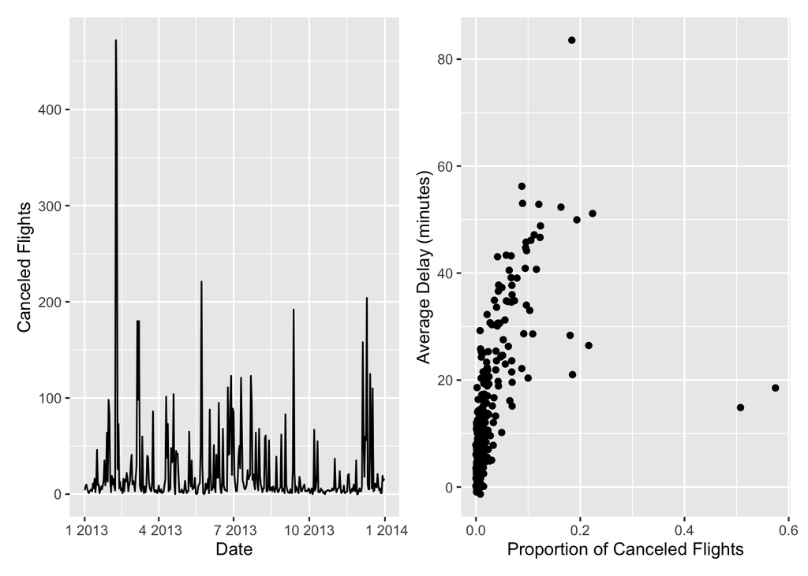

```r
library(patchwork)

p1 = flights %>%
  mutate(date = lubridate::make_datetime(year, month, day)) %>%
  group_by(date) %>%
  summarise(canceled = sum(is.na(dep_delay))) %>%
  ggplot(aes(x = date, y = canceled)) +
  geom_line() +
  xlab("Date") +
  ylab('Canceled Flights')

p2 = flights %>%
  mutate(date = lubridate::make_datetime(year, month, day)) %>%
  group_by(date) %>%
  summarise(canceled = sum(is.na(dep_delay)),
            n = n(),
            mean_dep_delay = mean(dep_delay, na.rm = TRUE)) %>%
  ggplot(aes(x = canceled / n, y = mean_dep_delay)) +
  geom_point() +
  xlab("Proportion of Canceled Flights") +
  ylab('Average Delay (minutes)')

p1+p2
```